# MATH 253 Topic 7 Exercises

Danny Kaplan

Statistical Computing and Machine Learning

## ISL 7.9.3

I’ll use R to do the sketching …

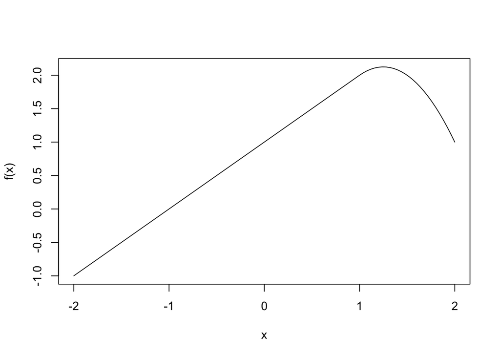

```r
x <- seq(-2, 2, length = 101)
f <- function(x) 1 + 1 * x - 2 * (x - 1)^2 * ((x - 1) > 0)
plot(x, f(x), type = "l")
```

## ISL 7.9.4

To start, let’s define an indicator function and the basis functions:

```r
indic <- function(x, low, high) ifelse(low <= x & x <= high, 1, 0)
b1 <- function(x) indic(x, 0, 2) - (x - 1) * indic(x, 1, 2)
b2 <- function(x) (x - 3) * indic(x, 3, 4) + indic(x, 4, 5)
```

(This could also be written `function(x, low, high) as.numeric((low <= x)*(x <= high))`.)

Then, the function is

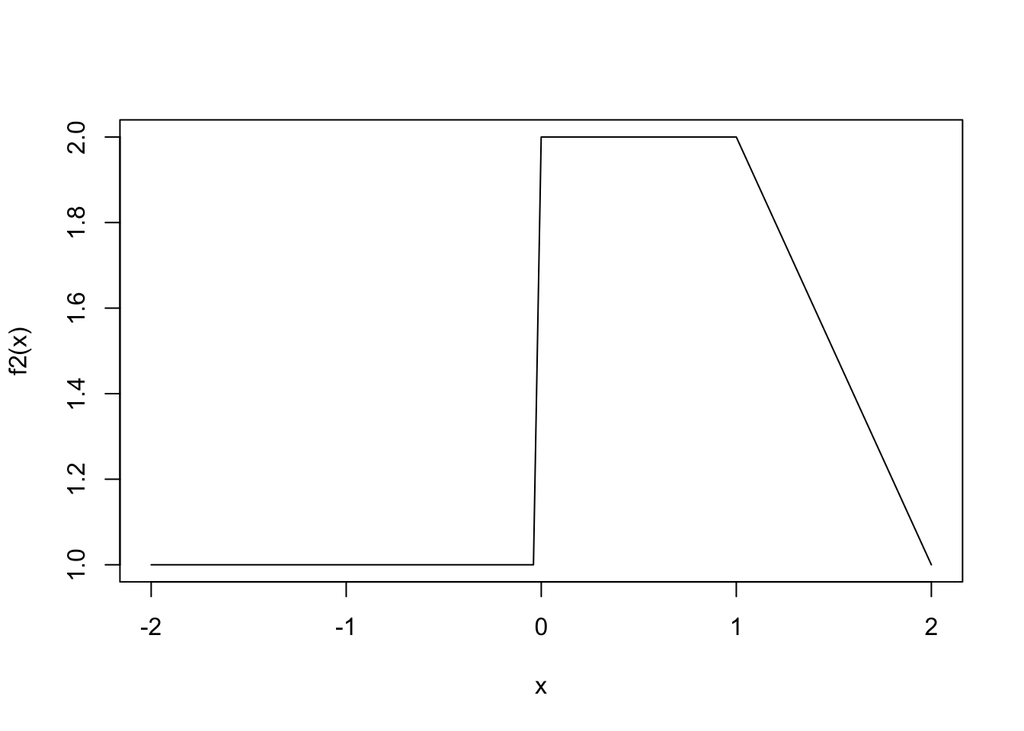

```r
beta_0 <- 1; beta_1 <- 1; beta_2 <- 3;
f2 <- function(x) beta_0 + beta_1 * b1(x) + beta_2 * b2(x)
plot(x, f2(x), type = 'l')
```

Note that `b2()` is always zero in the interval $x \in (-2, 2)$, so it’s not doing any of the work in this plot.

## ISL 7.9.5

As $\lambda \rightarrow \infty$, the second term in $\hat{g}_1$ dominates. This can be minimized by constructing any $g(x)$ whose third derivative is everywhere zero. Similarly, when $\lambda \rightarrow \infty$, $\hat{g}_2$ will be any function whose fourth derivative is everywhere zero.

In contrast, when $\lambda = 0$, the two functions are equal.

1. $g_2$ is more flexible (because it can have a non-zero third derivative, in contrast to $g_1$) so it will have the smaller training RSS.
2. Although $g_2$ is more flexible and therefore has lower bias, it may have higher variance. Test RSS is a combination of bias and variance. Without knowing the specifics, we can’t know if $g_1$ or $g_2$ has the smaller test RSS.
3. The two functions are exactly the same, so they have the same training RSS and they have the same testing RSS.

## ISL 7.9.11

1. Generate a response $Y$ and two predictors $X_1$ and $X_2$ with $n = 100$.

   ```r
   n <- 100
   X1 <- rnorm(n)
   X2 <- rnorm(n)
   Y <- 1 + 2 * X1 + 3 * X2
   ```

   The coefficients are, of course, arbitrary.
2. Initialize $\hat{\beta}_1$ to take on a value of your choice. It does not matter which.

   ```r
   beta_1 <- 20
   ```

3. Keeping $\hat{\beta}_1$ fixed, fit the model …

   ```r
   A <- Y - beta_1 * X1
   beta_2 <- lm(A ~ X2)$coef[2]
   ```

4. Keeping $\hat{\beta}_2$ fixed, fit the model

```r
A <- Y - beta_2 * X2
beta_1 <- lm(A ~ X1)$coef[2]
```

5. Do this repeatedly …

   ```r
   beta_1 <- 20 # re-initialize
   n <- 10
   results <- matrix(NA, ncol=3, nrow = n)
   for (k in 1:n) {
     A <- Y - beta_1 * X1
     beta_2 <- lm(A ~ X2)$coef[2]
     A <- Y - beta_2 * X2
     beta_1 <- lm(A ~ X1)$coef[2]
     beta_0 <- lm(A ~ X1)$coef[1]
     results[k, 1] <- beta_0
     results[k, 2] <- beta_1
     results[k, 3] <- beta_2
   }
   results
   ```

   ```
   ##            [,1]     [,2]     [,3]
   ##  [1,] 0.6524267 2.609549 6.299238
   ##  [2,] 0.9882298 2.020642 3.111725
   ##  [3,] 0.9996014 2.000699 3.003783
   ##  [4,] 0.9999865 2.000024 3.000128
   ##  [5,] 0.9999995 2.000001 3.000004
   ##  [6,] 1.0000000 2.000000 3.000000
   ##  [7,] 1.0000000 2.000000 3.000000
   ##  [8,] 1.0000000 2.000000 3.000000
   ##  [9,] 1.0000000 2.000000 3.000000
   ## [10,] 1.0000000 2.000000 3.000000
   ```

6. Do multiple regression

```r
betas <- lm(Y ~ X1 + X2)$coef
betas
```

```
## (Intercept)          X1          X2
##           1           2           3
```

```
Or, in plot form:
```

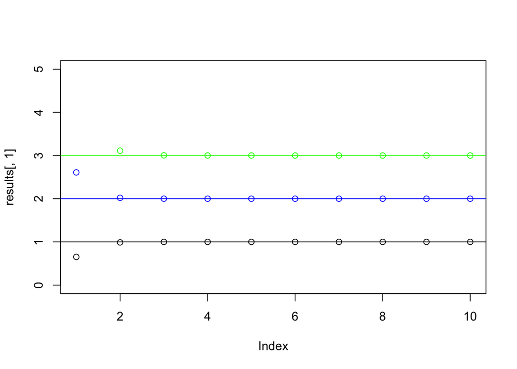

```r
plot(results[,1], ylim = c(0,5))
points(results[,2], col = "blue")
points(results[,3], col = "green")
abline(h = betas[1])
abline(h = betas[2], col = "blue")
abline(h = betas[3], col = "green")
```

7. Backfitting converged very quickly: by the sixth iteration we’re at the correct values.